# Latihan Pertemuan 4

Uiwang Nur Thoriq

2023-09-21

### Pembangkitan White Noise

```r
set.seed(020)
wn <- rnorm(300)
wn
```

```
##   [1]  1.162685290 -0.585924466  1.785465003 -1.332593710 -0.446566767
##   [6]  0.569606122 -2.889717614 -0.869018343 -0.461702683 -0.555540910
##  [11] -0.020135368 -0.150382224 -0.628126756  1.323220852 -1.521350570
##  [16] -0.437427869  0.970577580  0.028222644 -0.085782189  0.389214405
##  [21]  0.236687368 -0.144440227  0.722229701  0.369906857 -0.242066314
##  [26] -1.472063318 -0.596159546 -1.146700131 -2.474636433 -0.613508578
##  [31] -0.216311514  1.590145768  1.556143276  1.108450893 -1.097341845
##  [36] -1.860605716 -0.913578848  1.245568912  0.087854718  0.423481895
##  [41] -0.818483017 -1.542567837  0.555882146 -0.369028971 -1.047338280
##  [46]  0.018179916  0.881877506  0.881861495  1.026243185 -0.381309179
##  [51]  1.099435237 -0.030917131  0.190339420  1.335206535  0.730552335
##  [56]  0.056201897  1.329305630 -0.408119943 -0.818257107  0.358945670
##  [61]  0.058716060 -0.069436588 -0.384816268 -0.874323457  1.196330669
##  [66] -1.661199547  1.165212078 -1.069661978  0.908883540 -1.317507421
##  [71]  0.655429956 -0.660371824  0.991580769 -0.683223536  1.121321195
```

[output cut: 45 more lines]

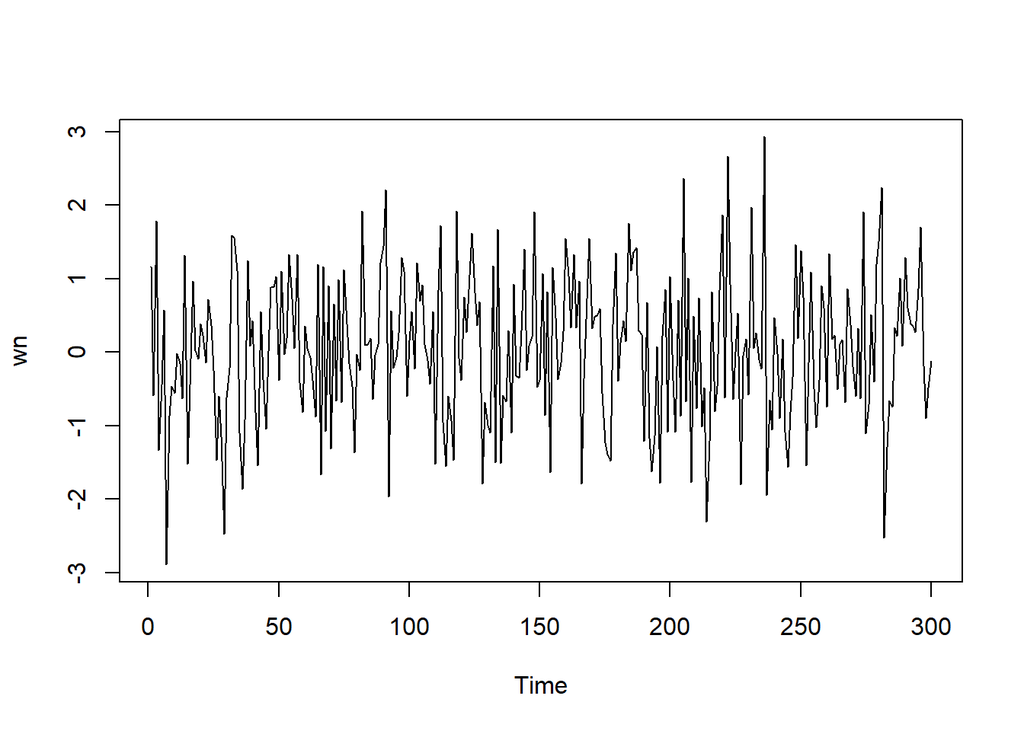

```r
ts.plot(wn)
```

### Proses MA(2)

Bangkitkan model MA(2) dengan 𝜃1 = 0.4 dan 𝜃2 = 0.6 sebanyak 300 data (Manual dan dengan arima.sim)

# Manual

```r
set.seed(020)
ma <- wn[c(1,2)]
ma
```

```
## [1]  1.1626853 -0.5859245
```

```r
for(i in 3:300){
   ma[i] <- wn[i] + 0.4 * wn[i - 1] + 0.6 * wn[i-2]
}
ma
```

```
##   [1]  1.162685290 -0.585924466  2.248706391 -0.969962389  0.091674751
##   [6] -0.408576811 -2.929815225 -1.683141716 -2.543140589 -1.261632989
##  [11] -0.519373342 -0.491760917 -0.700360866  0.981740815 -1.368938283
##  [16] -0.252035586 -0.117203910  0.153996955  0.507853417  0.371835116
##  [21]  0.340903817  0.183763363  0.806466031  0.572134602  0.339234249
##  [26] -1.346945730 -1.330224662 -2.268401941 -3.291012213 -2.291383230
##  [31] -1.946496805  1.135516016  2.062414675  2.684995665  0.279724478
##  [36] -1.634471918 -2.316226241 -0.236226057  0.037934974  1.205965130
##  [41] -0.596377428 -1.615871907 -0.552234799 -1.072216814 -0.861420581
##  [46] -0.622172778  0.260746504  1.245520447  1.908114287  0.558304992
##  [51]  1.562657476  0.180071456  0.837633710  1.392792024  1.378838601
##  [56]  1.149546752  1.790117789  0.157323448 -0.183921706 -0.213229138
##  [61] -0.288659936  0.169417238 -0.377361267 -1.069911917  0.615711525
##  [66] -1.707261354  1.218530661 -1.600296875  1.180145996 -1.595751192
##  [71]  0.673757112 -1.188704294  1.120690013 -0.682814323  1.442980242
```

[output cut: 45 more lines]

# Arima.simp

```r
set.seed(020)
ma2 <- arima.sim(list(order=c(0,0,2), ma=c(0.4,0.6)), n=300)
ma2
```

```
## Time Series:
## Start = 1
## End = 300
## Frequency = 1
##   [1]  2.248706391 -0.969962389  0.091674751 -0.408576811 -2.929815225
##   [6] -1.683141716 -2.543140589 -1.261632989 -0.519373342 -0.491760917
##  [11] -0.700360866  0.981740815 -1.368938283 -0.252035586 -0.117203910
##  [16]  0.153996955  0.507853417  0.371835116  0.340903817  0.183763363
##  [21]  0.806466031  0.572134602  0.339234249 -1.346945730 -1.330224662
##  [26] -2.268401941 -3.291012213 -2.291383230 -1.946496805  1.135516016
##  [31]  2.062414675  2.684995665  0.279724478 -1.634471918 -2.316226241
##  [36] -0.236226057  0.037934974  1.205965130 -0.596377428 -1.615871907
##  [41] -0.552234799 -1.072216814 -0.861420581 -0.622172778  0.260746504
##  [46]  1.245520447  1.908114287  0.558304992  1.562657476  0.180071456
##  [51]  0.837633710  1.392792024  1.378838601  1.149546752  1.790117789
```

[output cut: 49 more lines]

## Plot MA(2)

Buat plot time series, plot ACF, plot PACF dan plot EACF. Idenifikasiapakah data tersebut stasioner

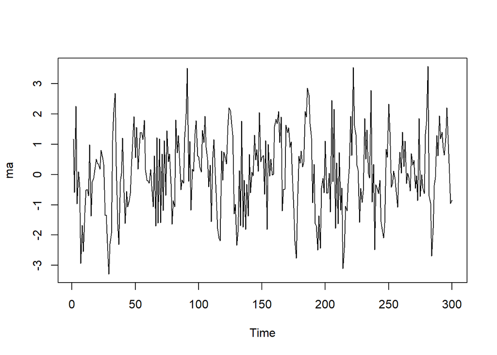

```r
# Plot Time Series
ts.plot(ma)
```

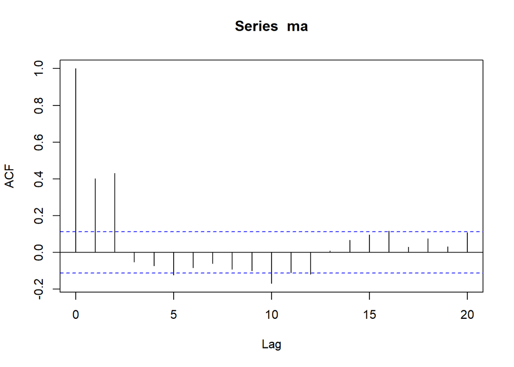

```r
#Plot ACF
acf(ma,lag.max = 20)
```

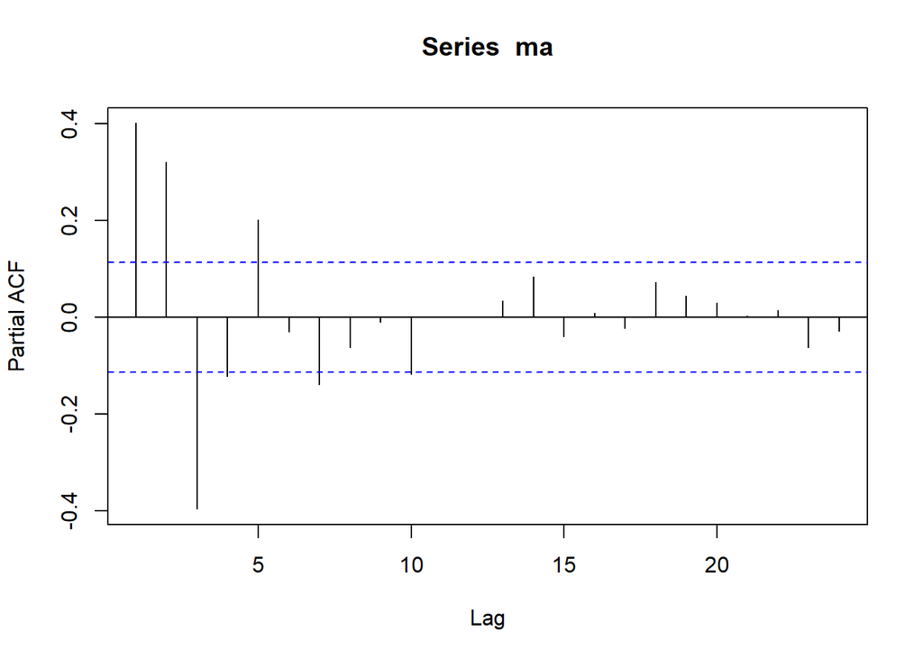

```
## AR/MA
##   0 1 2 3 4 5 6 7 8 9 10 11 12 13
## 0 x x o o x o o o o x o  o  o  o
## 1 x x x o o o o o o o o  o  o  o
## 2 x x x o o o o o o o o  o  o  o
## 3 x x x o x o o o o o o  o  o  o
## 4 x x x o x o o o o o o  o  o  o
## 5 x x x x o o x o o o o  o  o  o
## 6 x x o x o o x x o o o  o  o  o
## 7 x o o o x o o o o o o  o  o  o
```

```r
#Plot PACF
pacf(ma)

#Plot EACF
TSA::eacf(ma)
```

Berdasarkan plot times series tersebut, terlihat bahwa data cenderung stationer dalam rataan.

Berdasarkan plot AFC tersebut, terlihat bahwa plot ACF cuts off di lag kedua.

Berdasarkan plot PACF tersebut, terlihat bahwa plot PACF cenderung tails off dan membentuk gelombang sinus.

Berdasarkan pola segitiga nol pada plot EACF, terlihat bahwa segitiga nol berada pada ordo AR(0) dan ordo MA(2).

## Scatterplot

Buat scatterplot antara $Y_t$ dengan $Y_{t-1}$, $Y_t$ dengan $Y_{t-2}$ serta $Y_t$ dengan $Y_{t-3}$

#$Y_t$ dengan $Y_{t-1}$

```r
#Yt
yt_ma <- ma[-1]
yt_ma
```

```
##   [1] -0.585924466  2.248706391 -0.969962389  0.091674751 -0.408576811
##   [6] -2.929815225 -1.683141716 -2.543140589 -1.261632989 -0.519373342
##  [11] -0.491760917 -0.700360866  0.981740815 -1.368938283 -0.252035586
##  [16] -0.117203910  0.153996955  0.507853417  0.371835116  0.340903817
##  [21]  0.183763363  0.806466031  0.572134602  0.339234249 -1.346945730
##  [26] -1.330224662 -2.268401941 -3.291012213 -2.291383230 -1.946496805
##  [31]  1.135516016  2.062414675  2.684995665  0.279724478 -1.634471918
##  [36] -2.316226241 -0.236226057  0.037934974  1.205965130 -0.596377428
##  [41] -1.615871907 -0.552234799 -1.072216814 -0.861420581 -0.622172778
##  [46]  0.260746504  1.245520447  1.908114287  0.558304992  1.562657476
##  [51]  0.180071456  0.837633710  1.392792024  1.378838601  1.149546752
##  [56]  1.790117789  0.157323448 -0.183921706 -0.213229138 -0.288659936
##  [61]  0.169417238 -0.377361267 -1.069911917  0.615711525 -1.707261354
##  [66]  1.218530661 -1.600296875  1.180145996 -1.595751192  0.673757112
##  [71] -1.188704294  1.120690013 -0.682814323  1.442980242  0.427145646
```

[output cut: 45 more lines]

```r
#Yt-1
yt_1_ma <- ma[-300]
yt_1_ma
```

```
##   [1]  1.162685290 -0.585924466  2.248706391 -0.969962389  0.091674751
##   [6] -0.408576811 -2.929815225 -1.683141716 -2.543140589 -1.261632989
##  [11] -0.519373342 -0.491760917 -0.700360866  0.981740815 -1.368938283
##  [16] -0.252035586 -0.117203910  0.153996955  0.507853417  0.371835116
##  [21]  0.340903817  0.183763363  0.806466031  0.572134602  0.339234249
##  [26] -1.346945730 -1.330224662 -2.268401941 -3.291012213 -2.291383230
##  [31] -1.946496805  1.135516016  2.062414675  2.684995665  0.279724478
##  [36] -1.634471918 -2.316226241 -0.236226057  0.037934974  1.205965130
##  [41] -0.596377428 -1.615871907 -0.552234799 -1.072216814 -0.861420581
##  [46] -0.622172778  0.260746504  1.245520447  1.908114287  0.558304992
##  [51]  1.562657476  0.180071456  0.837633710  1.392792024  1.378838601
##  [56]  1.149546752  1.790117789  0.157323448 -0.183921706 -0.213229138
##  [61] -0.288659936  0.169417238 -0.377361267 -1.069911917  0.615711525
##  [66] -1.707261354  1.218530661 -1.600296875  1.180145996 -1.595751192
##  [71]  0.673757112 -1.188704294  1.120690013 -0.682814323  1.442980242
```

[output cut: 45 more lines]

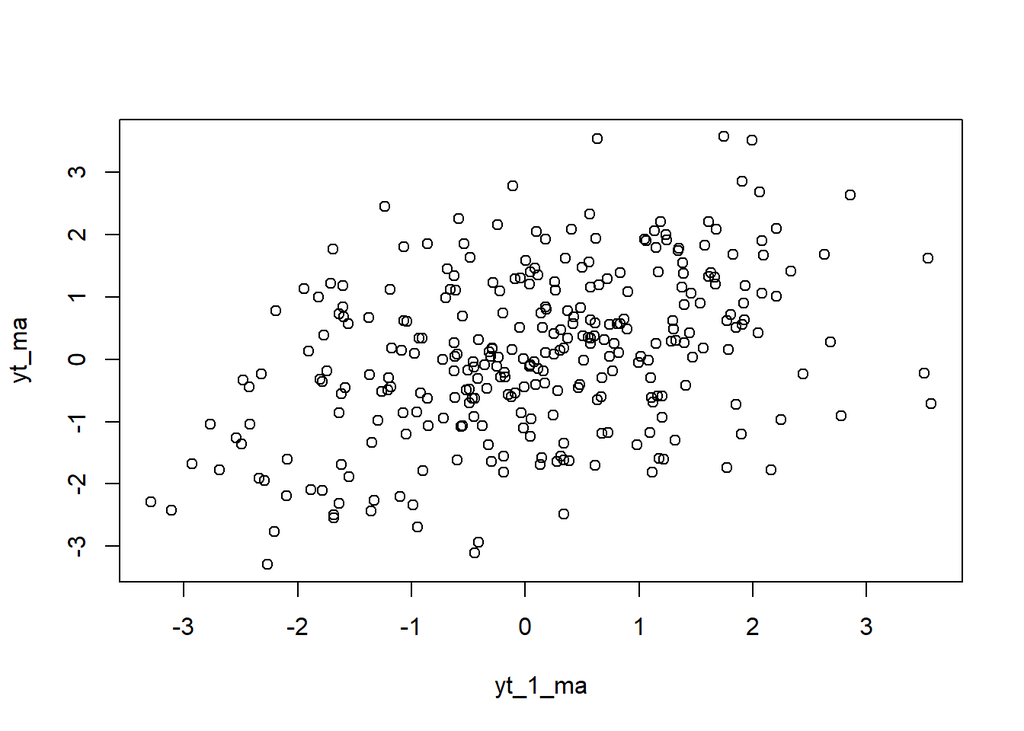

```r
plot(y=yt_ma,x=yt_1_ma)
```

Berdasarkan scatter plot terlihat ada hubungan positif antara $Y_t$ dengan $Y_{t-1}$

#$Y_t$ dengan $Y_{t-2}$

```r
#Yt
yt_ma2 <- ma[-c(1,2)]
yt_ma2
```

```
##   [1]  2.248706391 -0.969962389  0.091674751 -0.408576811 -2.929815225
##   [6] -1.683141716 -2.543140589 -1.261632989 -0.519373342 -0.491760917
##  [11] -0.700360866  0.981740815 -1.368938283 -0.252035586 -0.117203910
##  [16]  0.153996955  0.507853417  0.371835116  0.340903817  0.183763363
##  [21]  0.806466031  0.572134602  0.339234249 -1.346945730 -1.330224662
##  [26] -2.268401941 -3.291012213 -2.291383230 -1.946496805  1.135516016
##  [31]  2.062414675  2.684995665  0.279724478 -1.634471918 -2.316226241
##  [36] -0.236226057  0.037934974  1.205965130 -0.596377428 -1.615871907
##  [41] -0.552234799 -1.072216814 -0.861420581 -0.622172778  0.260746504
##  [46]  1.245520447  1.908114287  0.558304992  1.562657476  0.180071456
##  [51]  0.837633710  1.392792024  1.378838601  1.149546752  1.790117789
##  [56]  0.157323448 -0.183921706 -0.213229138 -0.288659936  0.169417238
##  [61] -0.377361267 -1.069911917  0.615711525 -1.707261354  1.218530661
##  [66] -1.600296875  1.180145996 -1.595751192  0.673757112 -1.188704294
##  [71]  1.120690013 -0.682814323  1.442980242  0.427145646  0.677446442
```

[output cut: 45 more lines]

```r
#Yt-2
yt_2_ma <- ma[-c(299,300)]
yt_2_ma
```

```
##   [1]  1.162685290 -0.585924466  2.248706391 -0.969962389  0.091674751
##   [6] -0.408576811 -2.929815225 -1.683141716 -2.543140589 -1.261632989
##  [11] -0.519373342 -0.491760917 -0.700360866  0.981740815 -1.368938283
##  [16] -0.252035586 -0.117203910  0.153996955  0.507853417  0.371835116
##  [21]  0.340903817  0.183763363  0.806466031  0.572134602  0.339234249
##  [26] -1.346945730 -1.330224662 -2.268401941 -3.291012213 -2.291383230
##  [31] -1.946496805  1.135516016  2.062414675  2.684995665  0.279724478
##  [36] -1.634471918 -2.316226241 -0.236226057  0.037934974  1.205965130
##  [41] -0.596377428 -1.615871907 -0.552234799 -1.072216814 -0.861420581
##  [46] -0.622172778  0.260746504  1.245520447  1.908114287  0.558304992
##  [51]  1.562657476  0.180071456  0.837633710  1.392792024  1.378838601
##  [56]  1.149546752  1.790117789  0.157323448 -0.183921706 -0.213229138
##  [61] -0.288659936  0.169417238 -0.377361267 -1.069911917  0.615711525
##  [66] -1.707261354  1.218530661 -1.600296875  1.180145996 -1.595751192
##  [71]  0.673757112 -1.188704294  1.120690013 -0.682814323  1.442980242
```

[output cut: 45 more lines]

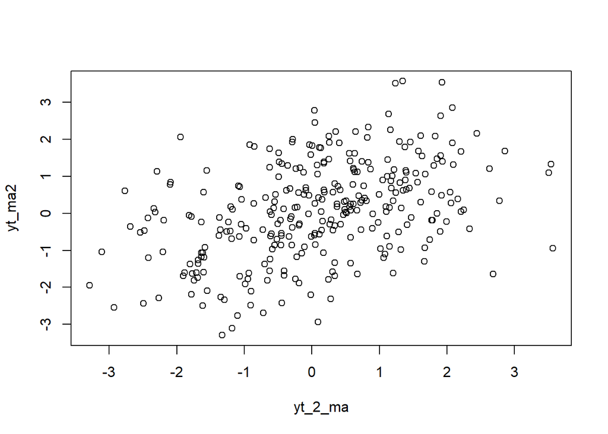

```r
plot(y=yt_ma2,x=yt_2_ma)
```

Berdasarkan scatter plot terlihat ada hubungan positif antara $Y_t$ dengan $Y_{t-2}$

#$Y_t$ dengan $Y_{t-3}$

```r
#Yt
yt_ma3 <- ma[-c(1,2,3)]
yt_ma3
```

```
##   [1] -0.969962389  0.091674751 -0.408576811 -2.929815225 -1.683141716
##   [6] -2.543140589 -1.261632989 -0.519373342 -0.491760917 -0.700360866
##  [11]  0.981740815 -1.368938283 -0.252035586 -0.117203910  0.153996955
##  [16]  0.507853417  0.371835116  0.340903817  0.183763363  0.806466031
##  [21]  0.572134602  0.339234249 -1.346945730 -1.330224662 -2.268401941
##  [26] -3.291012213 -2.291383230 -1.946496805  1.135516016  2.062414675
##  [31]  2.684995665  0.279724478 -1.634471918 -2.316226241 -0.236226057
##  [36]  0.037934974  1.205965130 -0.596377428 -1.615871907 -0.552234799
##  [41] -1.072216814 -0.861420581 -0.622172778  0.260746504  1.245520447
##  [46]  1.908114287  0.558304992  1.562657476  0.180071456  0.837633710
##  [51]  1.392792024  1.378838601  1.149546752  1.790117789  0.157323448
##  [56] -0.183921706 -0.213229138 -0.288659936  0.169417238 -0.377361267
##  [61] -1.069911917  0.615711525 -1.707261354  1.218530661 -1.600296875
##  [66]  1.180145996 -1.595751192  0.673757112 -1.188704294  1.120690013
##  [71] -0.682814323  1.442980242  0.427145646  0.677446442 -0.293152601
```

[output cut: 45 more lines]

```r
#Yt-3
yt_3_ma <- ma[-c(288,299,300)]
yt_3_ma
```

```
##   [1]  1.162685290 -0.585924466  2.248706391 -0.969962389  0.091674751
##   [6] -0.408576811 -2.929815225 -1.683141716 -2.543140589 -1.261632989
##  [11] -0.519373342 -0.491760917 -0.700360866  0.981740815 -1.368938283
##  [16] -0.252035586 -0.117203910  0.153996955  0.507853417  0.371835116
##  [21]  0.340903817  0.183763363  0.806466031  0.572134602  0.339234249
##  [26] -1.346945730 -1.330224662 -2.268401941 -3.291012213 -2.291383230
##  [31] -1.946496805  1.135516016  2.062414675  2.684995665  0.279724478
##  [36] -1.634471918 -2.316226241 -0.236226057  0.037934974  1.205965130
##  [41] -0.596377428 -1.615871907 -0.552234799 -1.072216814 -0.861420581
##  [46] -0.622172778  0.260746504  1.245520447  1.908114287  0.558304992
##  [51]  1.562657476  0.180071456  0.837633710  1.392792024  1.378838601
##  [56]  1.149546752  1.790117789  0.157323448 -0.183921706 -0.213229138
##  [61] -0.288659936  0.169417238 -0.377361267 -1.069911917  0.615711525
##  [66] -1.707261354  1.218530661 -1.600296875  1.180145996 -1.595751192
##  [71]  0.673757112 -1.188704294  1.120690013 -0.682814323  1.442980242
```

[output cut: 45 more lines]

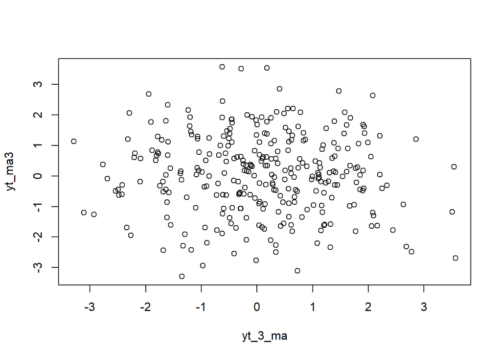

```r
plot(y=yt_ma3,x=yt_3_ma)
```

Berdasarkan scatter plot terlihat antara $Y_t$ dengan $Y_{t-3}$ cenderung tidak ada hubungan

## AutoKorelasi

Hitung autokorelasi masing masing baik dari data bangkitan maupun secara teoritis

```r
cor(yt_ma,yt_1_ma)
```

```
## [1] 0.4017609
```

```r
cor(yt_ma2,yt_2_ma)
```

```
## [1] 0.4319016
```

```r
cor(yt_ma3,yt_3_ma)
```

```
## [1] -0.04895376
```

$$\rho_1=\frac{-\theta_1+\theta_1\theta_2}{1+\theta_1^2+\theta_2^2}=\frac{-(-0.4)+(-0.4)(-0.6)}{1+(-0.4)^2+(-0.6)^2}=0.42$$

$$\rho_2=\frac{-\theta_2}{1+\theta_1^2+\theta_2^2}=\frac{-(-0.6)}{1+(-0.4)^2+(-0.6)^2}=0.39$$
Korelasi antara $Y_t$ dengan $Y_{t-1}$ dari hasil simulasi mendekati perhitungan teoritisnya. Korelasi antara $Y_t$ dengan $Y_{t-2}$ dari hasil simulasi mendekati perhitungan teoritisnya. Korelasi antara $Y_t$ dengan $Y_{t-3}$ dari hasil simulasi mendekati perhitungan teoritisnya $Korelasi = 0$.

### Proses AR(2)

Bangkitkan model AR(2) dengan 𝜙1 = 0.5 dan 𝜙2 = 0.2 sebanyak 300 data (Manual dan dengan arima.sim)

#Manual

```r
set.seed(020)
n<-length(wn)
n
```

```
## [1] 300
```

```r
ar <- c(1:n)
for (i in 3:n) {ar[i]<-wn[i]+0.5*ar[i-1]+0.2*ar[i-2]}
ar
```

```
##   [1]  1.000000000  2.000000000  2.985465003  0.560138791  0.430595630
##   [6]  0.896931695 -2.355132641 -1.867198325 -1.866328374 -1.862144762
##  [11] -1.324473424 -1.185047888 -1.485545385  0.343438582 -1.646740356
##  [16] -1.192110330  0.045174343 -0.187612250 -0.170553445  0.266415232
##  [21]  0.335784295  0.076734967  0.827754043  0.799130873  0.323049930
##  [26] -1.150712179 -1.106905649 -1.930295391 -3.661165259 -2.830150286
##  [31] -2.363619709 -0.157694143  1.004572262  1.579198196 -0.106828294
##  [36] -1.598180224 -1.734034619  0.058915558 -0.229494427  0.320517793
##  [41] -0.704123005 -1.830525781 -0.500205346 -0.985236800 -1.639997749
##  [46] -0.998866318  0.054444797  0.709310630  1.391787460  0.456446676
##  [51]  1.606016067  0.863380238  0.943232752  1.979498959  1.908948364
##  [56]  1.406575871  2.414383238  1.080386851  0.204812966  0.677429523
##  [61]  0.438393415  0.285246024 -0.154514573 -0.894531539  0.718161984
##  [66] -1.481024863  0.568332044 -1.081700928  0.481699485 -1.292997864
##  [71]  0.105270921 -0.866335936  0.579466985 -0.566757231  0.953835977
```

[output cut: 45 more lines]

#Arima.Simp

```r
set.seed(020)
ar2 <- arima.sim(list(order=c(2,0,0), ar=c(0.5,0.2)), n=300)
ar2
```

```
## Time Series:
## Start = 1
## End = 300
## Frequency = 1
##   [1] -1.152879422 -1.108557842 -1.931554936 -3.662125470 -2.830882300
##   [6] -2.364177758 -0.158119571  1.004247939  1.578950949 -0.107016783
##  [11] -1.598323918 -1.734144164  0.058832047 -0.229558091  0.320469259
##  [16] -0.704160005 -1.830553988 -0.500226849 -0.985253193 -1.640010246
##  [21] -0.998875845  0.054437534  0.709305093  1.391783238  0.456443458
##  [26]  1.606013614  0.863378368  0.943231327  1.979497872  1.908947536
##  [31]  1.406575239  2.414382757  1.080386484  0.204812686  0.677429310
##  [36]  0.438393252  0.285245900 -0.154514667 -0.894531611  0.718161929
##  [41] -1.481024904  0.568332012 -1.081700953  0.481699466 -1.292997878
##  [46]  0.105270910 -0.866335945  0.579466978 -0.566757236  0.953835973
##  [51]  0.752117829  0.416059318 -0.107523433 -1.331065492 -0.716623193
```

[output cut: 49 more lines]

## Plot AR(2)

Buat plot time series, plot ACF, plot PACF dan plot EACF. Identifikasi apakah data tersebut stasioner

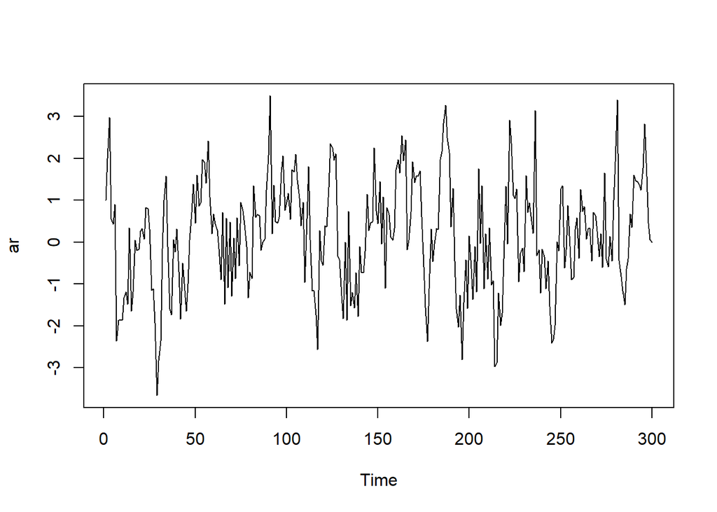

```r
#Plot time series
ts.plot(ar)
```

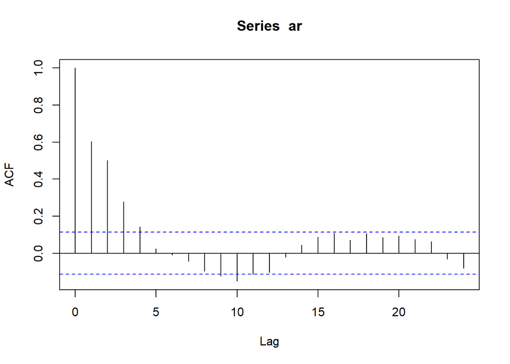

```r
#Plot ACF
acf(ar)
```

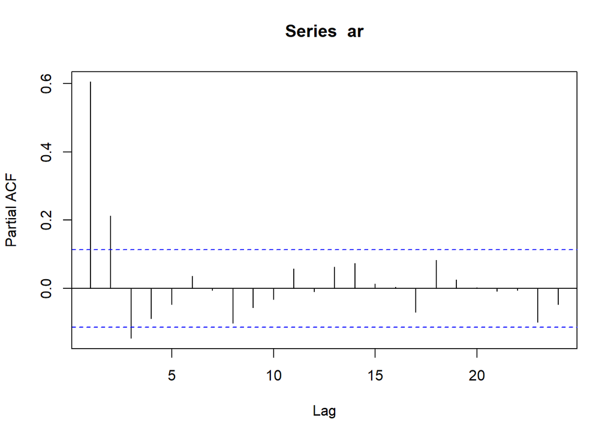

```r
#Plot PACF
pacf(ar)
```

```r
#Plot EACF
TSA::eacf(ar)
```

```
## AR/MA
##   0 1 2 3 4 5 6 7 8 9 10 11 12 13
## 0 x x x x o o o o x x o  o  o  o
## 1 x x o x o o o o o o o  o  o  o
## 2 x x o x o o o o o o o  o  o  o
## 3 x o x o o o o o o o o  o  o  o
## 4 x o x o x o o o o o o  o  o  o
## 5 x o x o x o o o o o o  o  o  o
## 6 x o x o x o o o o o o  o  o  o
## 7 o x x o x x o o o o o  o  o  o
```

Berdasarkan plot times series tersebut, terlihat bahwa data cenderung stationer dalam rataan.

Berdasarkan plot ACF tersebut terlihat bahwa plot ACF cenderung tails off dan cenderung membentuk pola grafik sinus.

Berdasarkan plot PACF tersebut, terlihat bahwa plot PACF cuts off pada lag kedua.

Berdasarkan pola segitiga nol pada plot EACF, terlihat bahwa segitiga nol berada pada ordo AR(1) dan ordo MA(2)

##Scatterplot Buat scatterplot antara $Y_t$ dengan $Y_{t-1}$, $Y_t$ dengan $Y_{t-2}$ serta $Y_t$ dengan $Y_{t-3}$

#$Y_t$ dengan $Y_{t-1}$

```r
#Yt
yt_ar <- ar[-1]
yt_ar
```

```
##   [1]  2.000000000  2.985465003  0.560138791  0.430595630  0.896931695
##   [6] -2.355132641 -1.867198325 -1.866328374 -1.862144762 -1.324473424
##  [11] -1.185047888 -1.485545385  0.343438582 -1.646740356 -1.192110330
##  [16]  0.045174343 -0.187612250 -0.170553445  0.266415232  0.335784295
##  [21]  0.076734967  0.827754043  0.799130873  0.323049930 -1.150712179
##  [26] -1.106905649 -1.930295391 -3.661165259 -2.830150286 -2.363619709
##  [31] -0.157694143  1.004572262  1.579198196 -0.106828294 -1.598180224
##  [36] -1.734034619  0.058915558 -0.229494427  0.320517793 -0.704123005
##  [41] -1.830525781 -0.500205346 -0.985236800 -1.639997749 -0.998866318
##  [46]  0.054444797  0.709310630  1.391787460  0.456446676  1.606016067
##  [51]  0.863380238  0.943232752  1.979498959  1.908948364  1.406575871
##  [56]  2.414383238  1.080386851  0.204812966  0.677429523  0.438393415
##  [61]  0.285246024 -0.154514573 -0.894531539  0.718161984 -1.481024863
##  [66]  0.568332044 -1.081700928  0.481699485 -1.292997864  0.105270921
##  [71] -0.866335936  0.579466985 -0.566757231  0.953835977  0.752117832
```

[output cut: 45 more lines]

```r
#Yt-1
yt_1_ar <- ar[-300]
yt_1_ar
```

```
##   [1]  1.000000000  2.000000000  2.985465003  0.560138791  0.430595630
##   [6]  0.896931695 -2.355132641 -1.867198325 -1.866328374 -1.862144762
##  [11] -1.324473424 -1.185047888 -1.485545385  0.343438582 -1.646740356
##  [16] -1.192110330  0.045174343 -0.187612250 -0.170553445  0.266415232
##  [21]  0.335784295  0.076734967  0.827754043  0.799130873  0.323049930
##  [26] -1.150712179 -1.106905649 -1.930295391 -3.661165259 -2.830150286
##  [31] -2.363619709 -0.157694143  1.004572262  1.579198196 -0.106828294
##  [36] -1.598180224 -1.734034619  0.058915558 -0.229494427  0.320517793
##  [41] -0.704123005 -1.830525781 -0.500205346 -0.985236800 -1.639997749
##  [46] -0.998866318  0.054444797  0.709310630  1.391787460  0.456446676
##  [51]  1.606016067  0.863380238  0.943232752  1.979498959  1.908948364
##  [56]  1.406575871  2.414383238  1.080386851  0.204812966  0.677429523
##  [61]  0.438393415  0.285246024 -0.154514573 -0.894531539  0.718161984
##  [66] -1.481024863  0.568332044 -1.081700928  0.481699485 -1.292997864
##  [71]  0.105270921 -0.866335936  0.579466985 -0.566757231  0.953835977
```

[output cut: 45 more lines]

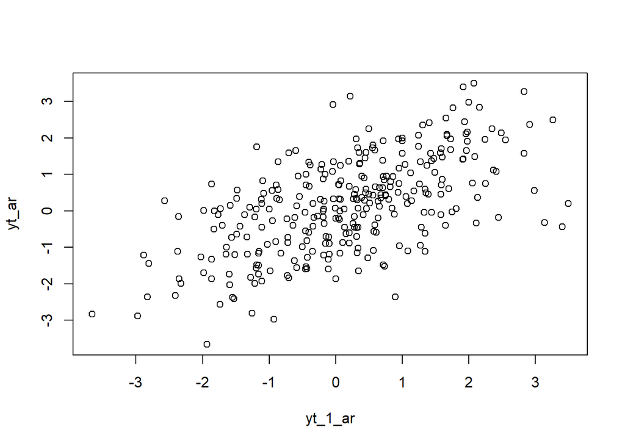

```r
plot(y=yt_ar,x=yt_1_ar)
```

Berdasarkan scatter plot terlihat ada hubungan positif antara $Y_t$ dengan $Y_{t-1}$

#$Y_t$ dengan $Y_{t-2}$

```r
#Yt
yt_ar2 <- ar[-c(1,2)]
yt_ar2
```

```
##   [1]  2.985465003  0.560138791  0.430595630  0.896931695 -2.355132641
##   [6] -1.867198325 -1.866328374 -1.862144762 -1.324473424 -1.185047888
##  [11] -1.485545385  0.343438582 -1.646740356 -1.192110330  0.045174343
##  [16] -0.187612250 -0.170553445  0.266415232  0.335784295  0.076734967
##  [21]  0.827754043  0.799130873  0.323049930 -1.150712179 -1.106905649
##  [26] -1.930295391 -3.661165259 -2.830150286 -2.363619709 -0.157694143
##  [31]  1.004572262  1.579198196 -0.106828294 -1.598180224 -1.734034619
##  [36]  0.058915558 -0.229494427  0.320517793 -0.704123005 -1.830525781
##  [41] -0.500205346 -0.985236800 -1.639997749 -0.998866318  0.054444797
##  [46]  0.709310630  1.391787460  0.456446676  1.606016067  0.863380238
##  [51]  0.943232752  1.979498959  1.908948364  1.406575871  2.414383238
##  [56]  1.080386851  0.204812966  0.677429523  0.438393415  0.285246024
##  [61] -0.154514573 -0.894531539  0.718161984 -1.481024863  0.568332044
##  [66] -1.081700928  0.481699485 -1.292997864  0.105270921 -0.866335936
##  [71]  0.579466985 -0.566757231  0.953835977  0.752117832  0.416059320
```

[output cut: 45 more lines]

```r
#Yt-2
yt_2_ar <- ar[-c(299,300)]
yt_2_ar
```

```
##   [1]  1.000000000  2.000000000  2.985465003  0.560138791  0.430595630
##   [6]  0.896931695 -2.355132641 -1.867198325 -1.866328374 -1.862144762
##  [11] -1.324473424 -1.185047888 -1.485545385  0.343438582 -1.646740356
##  [16] -1.192110330  0.045174343 -0.187612250 -0.170553445  0.266415232
##  [21]  0.335784295  0.076734967  0.827754043  0.799130873  0.323049930
##  [26] -1.150712179 -1.106905649 -1.930295391 -3.661165259 -2.830150286
##  [31] -2.363619709 -0.157694143  1.004572262  1.579198196 -0.106828294
##  [36] -1.598180224 -1.734034619  0.058915558 -0.229494427  0.320517793
##  [41] -0.704123005 -1.830525781 -0.500205346 -0.985236800 -1.639997749
##  [46] -0.998866318  0.054444797  0.709310630  1.391787460  0.456446676
##  [51]  1.606016067  0.863380238  0.943232752  1.979498959  1.908948364
##  [56]  1.406575871  2.414383238  1.080386851  0.204812966  0.677429523
##  [61]  0.438393415  0.285246024 -0.154514573 -0.894531539  0.718161984
##  [66] -1.481024863  0.568332044 -1.081700928  0.481699485 -1.292997864
##  [71]  0.105270921 -0.866335936  0.579466985 -0.566757231  0.953835977
```

[output cut: 45 more lines]

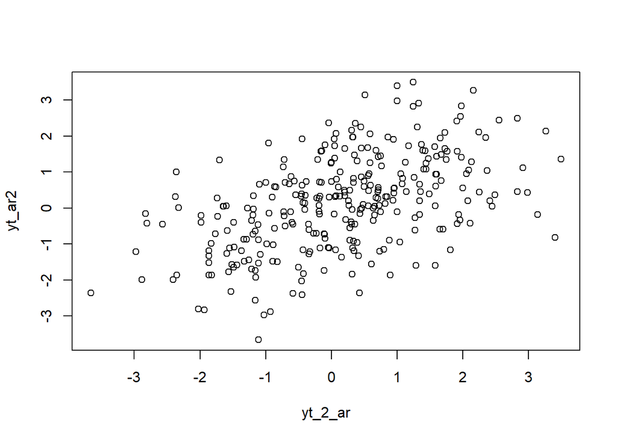

```r
plot(y=yt_ar2,x=yt_2_ar)
```

Berdasarkan scatter plot terlihat ada hubungan positif antara $Y_t$ dengan $Y_{t-2}$

#$Y_t$ dengan $Y_{t-3}$

```r
#Yt
yt_ar3 <- ar[-c(1,2,3)]
yt_ar3
```

```
##   [1]  0.560138791  0.430595630  0.896931695 -2.355132641 -1.867198325
##   [6] -1.866328374 -1.862144762 -1.324473424 -1.185047888 -1.485545385
##  [11]  0.343438582 -1.646740356 -1.192110330  0.045174343 -0.187612250
##  [16] -0.170553445  0.266415232  0.335784295  0.076734967  0.827754043
##  [21]  0.799130873  0.323049930 -1.150712179 -1.106905649 -1.930295391
##  [26] -3.661165259 -2.830150286 -2.363619709 -0.157694143  1.004572262
##  [31]  1.579198196 -0.106828294 -1.598180224 -1.734034619  0.058915558
##  [36] -0.229494427  0.320517793 -0.704123005 -1.830525781 -0.500205346
##  [41] -0.985236800 -1.639997749 -0.998866318  0.054444797  0.709310630
##  [46]  1.391787460  0.456446676  1.606016067  0.863380238  0.943232752
##  [51]  1.979498959  1.908948364  1.406575871  2.414383238  1.080386851
##  [56]  0.204812966  0.677429523  0.438393415  0.285246024 -0.154514573
##  [61] -0.894531539  0.718161984 -1.481024863  0.568332044 -1.081700928
##  [66]  0.481699485 -1.292997864  0.105270921 -0.866335936  0.579466985
##  [71] -0.566757231  0.953835977  0.752117832  0.416059320 -0.107523432
```

[output cut: 45 more lines]

```r
#Yt-3
yt_3_ar <- ar[-c(298,299,300)]
yt_3_ar
```

```
##   [1]  1.000000000  2.000000000  2.985465003  0.560138791  0.430595630
##   [6]  0.896931695 -2.355132641 -1.867198325 -1.866328374 -1.862144762
##  [11] -1.324473424 -1.185047888 -1.485545385  0.343438582 -1.646740356
##  [16] -1.192110330  0.045174343 -0.187612250 -0.170553445  0.266415232
##  [21]  0.335784295  0.076734967  0.827754043  0.799130873  0.323049930
##  [26] -1.150712179 -1.106905649 -1.930295391 -3.661165259 -2.830150286
##  [31] -2.363619709 -0.157694143  1.004572262  1.579198196 -0.106828294
##  [36] -1.598180224 -1.734034619  0.058915558 -0.229494427  0.320517793
##  [41] -0.704123005 -1.830525781 -0.500205346 -0.985236800 -1.639997749
##  [46] -0.998866318  0.054444797  0.709310630  1.391787460  0.456446676
##  [51]  1.606016067  0.863380238  0.943232752  1.979498959  1.908948364
##  [56]  1.406575871  2.414383238  1.080386851  0.204812966  0.677429523
##  [61]  0.438393415  0.285246024 -0.154514573 -0.894531539  0.718161984
##  [66] -1.481024863  0.568332044 -1.081700928  0.481699485 -1.292997864
##  [71]  0.105270921 -0.866335936  0.579466985 -0.566757231  0.953835977
```

[output cut: 45 more lines]

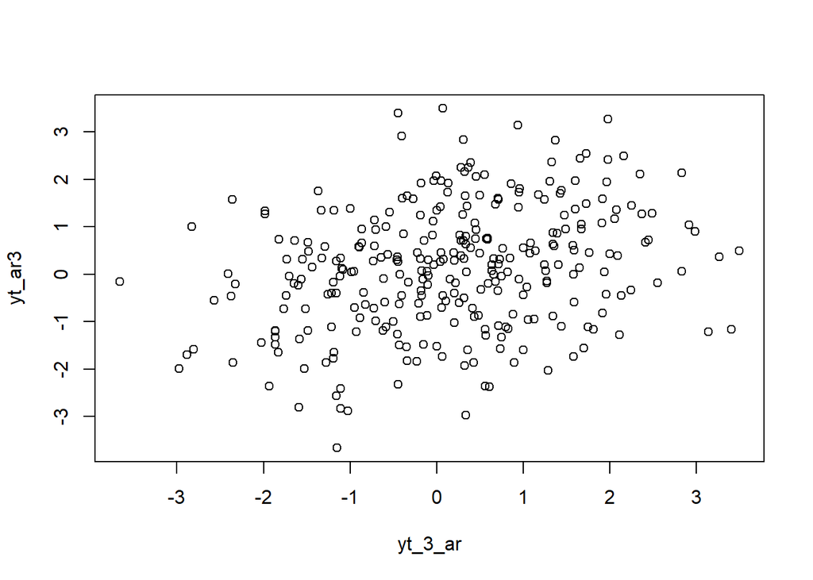

```r
plot(y=yt_ar3,x=yt_3_ar)
```

## AutoKorelasi

Hitung autokorelasi masing masing baik dari data bangkitan maupun secara teoritis

```r
cor(yt_ar,yt_1_ar)
```

```
## [1] 0.6049738
```

```r
cor(yt_ar2,yt_2_ar)
```

```
## [1] 0.5025619
```

```r
cor(yt_ar3,yt_3_ar)
```

```
## [1] 0.2819928
```

$$\rho_1=\frac{\phi_1}{1-\phi_2}=\frac{0.5}{1-0.2}=0.625$$
$$\rho_2=\frac{\phi_2(1-\phi_2)+\phi_1^2}{1-\phi_2}=\frac{0.2(1-0.2)+0.5^2}{1-0.2}=0.5125$$
$$\rho_3=\phi_1 \rho_2 + \phi_2 \rho_1=0.5*0.5125+0.2*0.625=0.38125$$
Korelasi antara $Y_t$ dengan $Y_{t-1}$ dari hasil simulasi mendekati perhitungan teoritisnya. Korelasi antara $Y_t$ dengan $Y_{t-2}$ dari hasil simulasi mendekati perhitungan teoritisnya. Korelasi antara $Y_t$ dengan $Y_{t-3}$ dari hasil simulasi mendekati perhitungan teoritisnya.

### Proses ARMA (2,2)

Bangkitkan model AR(2) dengan 𝜃1 = 0.4, 𝜃2 = 0.6,𝜙1 = 0.5 dan 𝜙2 = 0.2 sebanyak 300 data (Manual dan arima.sim)

#Manual

```r
set.seed(020)
n = length(wn)
phi1 = 0.5
phi2 = 0.2
theta1 = 0.4
theta2 = 0.6

arma=c(1:n)
for (i in 3:n){arma[i] = phi1*arma[i-1] + phi2*arma[i-2] + theta1*wn[i-1] + theta2*wn[i-2] + wn[i]}
arma
```

```
##   [1]  1.000000000  2.000000000  3.448706391  1.154390807  1.358611433
##   [6]  0.501607067 -2.407289405 -2.786465005 -4.417830973 -4.027841477
##  [11] -3.416860275 -3.005759350 -2.886612596 -1.062717353 -2.477619478
##  [16] -1.703388796 -1.464422203 -0.918891906 -0.244476977  0.065818247
##  [21]  0.324917544  0.359385785  1.051142432  1.169582975  1.134254223
##  [26] -0.545902023 -1.376324829 -3.065744760 -5.099149559 -5.454106962
##  [31] -5.693380198 -2.801995475 -0.477259103  1.885967018  1.127256167
##  [36] -0.693650431 -2.437600224 -1.593756255 -1.246463198  0.263982280
##  [41] -0.713678927 -1.919914914 -1.654928042 -2.283663818 -2.334238098
##  [46] -2.246024591 -1.329113411  0.131758824  1.708171016  1.438742265
##  [51]  2.623662812  1.779651315  2.252191930  2.874818252  3.266686113
##  [56]  3.357853459  4.122381741  2.890085010  2.085597147  1.407586437
##  [61]  0.832252712  0.867060881  0.222619716 -0.785189883  0.267640526
##  [66] -1.730479067  0.406819232 -1.742983072  0.390018307 -1.749338653
##  [71] -0.122908553 -1.600026301  0.296095151 -0.854772008  1.074813268
```

[output cut: 45 more lines]

#Arima.simp

```r
arma22 <- arima.sim(list(order=c(2,0,2), ar = c(0.5,0.2), ma = c(0.4,0.6)), n=300)
arma22
```

```
## Time Series:
## Start = 1
## End = 300
## Frequency = 1
##   [1] -3.067197192 -5.100256816 -5.454951077 -5.694023707 -2.802486053
##   [6] -0.477633093  1.885681908  1.127038813 -0.693816130 -2.437726544
##  [11] -1.593852555 -1.246536612  0.263926313 -0.713721594 -1.919947441
##  [16] -1.654952838 -2.283682722 -2.334252509 -2.246035577 -1.329121786
##  [21]  0.131752439  1.708166149  1.438738554  2.623659983  1.779649159
##  [26]  2.252190286  2.874816999  3.266685157  3.357852730  4.122381186
##  [31]  2.890084587  2.085596824  1.407586191  0.832252525  0.867060738
##  [36]  0.222619607 -0.785189966  0.267640463 -1.730479116  0.406819195
##  [41] -1.742983100  0.390018285 -1.749338669 -0.122908566 -1.600026311
##  [46]  0.296095144 -0.854772013  1.074813264  0.793597876  1.289208033
##  [51]  0.510170991 -1.124439275 -1.313563450 -1.950580496  0.569838204
```

[output cut: 49 more lines]

##Plot ARMA(2,2) Buat plot time series, plot ACF, plot PACF dan plot EACF.Idenifikasi apakah data tersebut stasioner

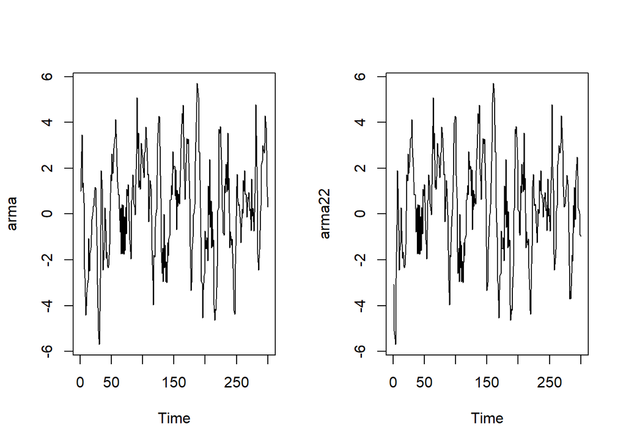

```r
#Plot Time Series
par(mfrow = c(1, 2))
ts.plot(arma)
ts.plot(arma22)
```

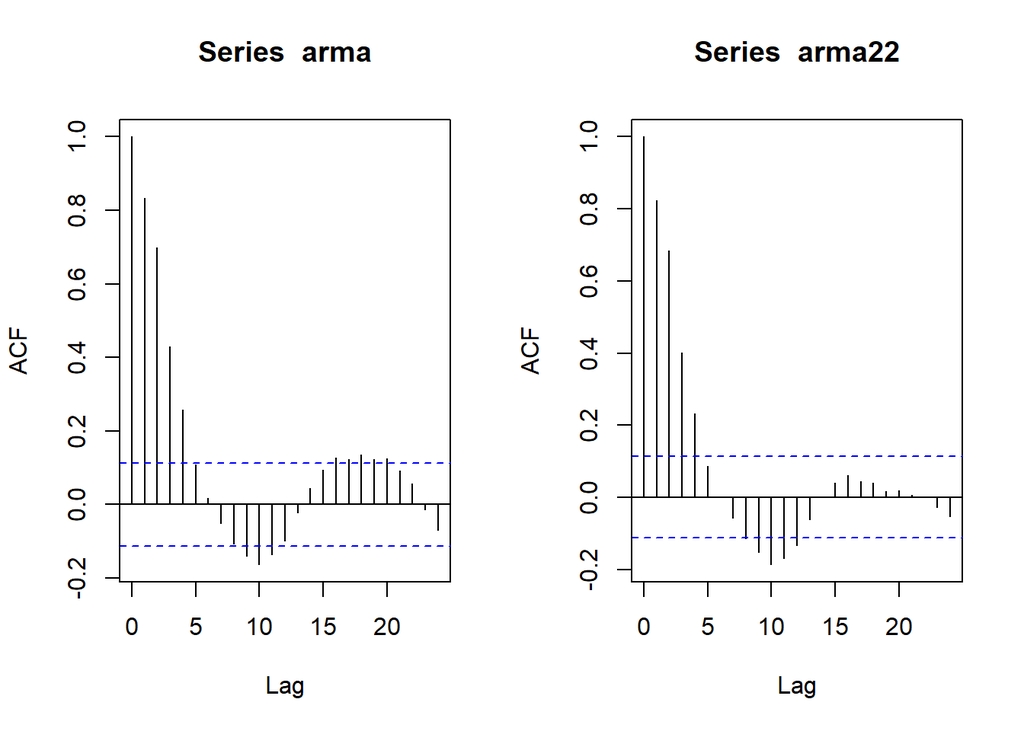

```r
#Plot ACF
acf(arma)
acf(arma22)
```

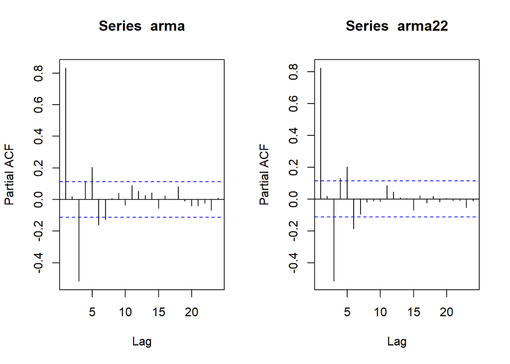

```r
#Plot PACF
pacf(arma)
pacf(arma22)
```

```r
#Plot EACF
TSA::eacf(arma)
```

```
## AR/MA
##   0 1 2 3 4 5 6 7 8 9 10 11 12 13
## 0 x x x x o o o o x x x  o  o  o
## 1 o x o x o o o o o x o  o  o  o
## 2 o x o x o o o o o o o  o  o  o
## 3 x x x x o o x o o o o  o  o  o
## 4 x x x o x o o o o o o  o  o  o
## 5 x x x o x o o o o o o  o  o  o
## 6 x x o x x o o x o o o  o  o  o
## 7 o x o o x o o o o o o  o  o  o
```

```r
TSA::eacf(arma22)
```

```
## AR/MA
##   0 1 2 3 4 5 6 7 8 9 10 11 12 13
## 0 x x x x o o o o x x x  x  o  o
## 1 o x o x o o o o o x o  x  o  o
## 2 o x o x o o o o o o o  o  o  o
## 3 x x x x o o x o o o o  o  o  o
## 4 x x x o x o x o o o o  o  o  o
## 5 x x x x x o x o x o o  o  o  o
## 6 x x o o x o o o o o o  o  o  o
## 7 x o x o x o o o o o o  o  o  o
```

Berdasarkan plot times series tersebut, terlihat bahwa data cenderung stationer dalam rataan.

Berdasarkan plot ACF tersebut terlihat bahwa plot ACF tails off.

Berdasarkan plot PACF tersebut, terlihat bahwa plot PACF tails off.

Berdasarkan pola segitiga nol pada plot EACF, terlihat bahwa segitiga nol berada pada ordo AR(0) dan ordo MA(4)

## Scatterplot

Buat scatterplot antara $Y_t$ dengan $Y_{t-1}$, $Y_t$ dengan $Y_{t-2}$ serta $Y_t$ dengan $Y_{t-3}$

#$Y_t$ dengan $Y_{t-1}$

```r
#Yt
yt_arma <- arma22[-1]
yt_arma
```

```
##   [1] -5.100256816 -5.454951077 -5.694023707 -2.802486053 -0.477633093
##   [6]  1.885681908  1.127038813 -0.693816130 -2.437726544 -1.593852555
##  [11] -1.246536612  0.263926313 -0.713721594 -1.919947441 -1.654952838
##  [16] -2.283682722 -2.334252509 -2.246035577 -1.329121786  0.131752439
##  [21]  1.708166149  1.438738554  2.623659983  1.779649159  2.252190286
##  [26]  2.874816999  3.266685157  3.357852730  4.122381186  2.890084587
##  [31]  2.085596824  1.407586191  0.832252525  0.867060738  0.222619607
##  [36] -0.785189966  0.267640463 -1.730479116  0.406819195 -1.742983100
##  [41]  0.390018285 -1.749338669 -0.122908566 -1.600026311  0.296095144
##  [46] -0.854772013  1.074813264  0.793597876  1.289208033  0.510170991
##  [51] -1.124439275 -1.313563450 -1.950580496  0.569838204  0.616238224
##  [56]  1.706300125  1.260106720  0.464285510  0.306328115 -0.038787800
##  [61]  1.276181176  2.622431808  5.077621916  2.842891746  3.533279655
##  [66]  1.161271856  1.467981061  1.075553948  2.183060872  3.081828874
##  [71]  2.593931016  2.490920832  2.017044396  1.593412259  2.655814355
```

[output cut: 45 more lines]

```r
#Yt-1
yt_1_arma <- arma22[-300]
yt_1_arma
```

```
##   [1] -3.067197192 -5.100256816 -5.454951077 -5.694023707 -2.802486053
##   [6] -0.477633093  1.885681908  1.127038813 -0.693816130 -2.437726544
##  [11] -1.593852555 -1.246536612  0.263926313 -0.713721594 -1.919947441
##  [16] -1.654952838 -2.283682722 -2.334252509 -2.246035577 -1.329121786
##  [21]  0.131752439  1.708166149  1.438738554  2.623659983  1.779649159
##  [26]  2.252190286  2.874816999  3.266685157  3.357852730  4.122381186
##  [31]  2.890084587  2.085596824  1.407586191  0.832252525  0.867060738
##  [36]  0.222619607 -0.785189966  0.267640463 -1.730479116  0.406819195
##  [41] -1.742983100  0.390018285 -1.749338669 -0.122908566 -1.600026311
##  [46]  0.296095144 -0.854772013  1.074813264  0.793597876  1.289208033
##  [51]  0.510170991 -1.124439275 -1.313563450 -1.950580496  0.569838204
##  [56]  0.616238224  1.706300125  1.260106720  0.464285510  0.306328115
##  [61] -0.038787800  1.276181176  2.622431808  5.077621916  2.842891746
##  [66]  3.533279655  1.161271856  1.467981061  1.075553948  2.183060872
##  [71]  3.081828874  2.593931016  2.490920832  2.017044396  1.593412259
```

[output cut: 45 more lines]

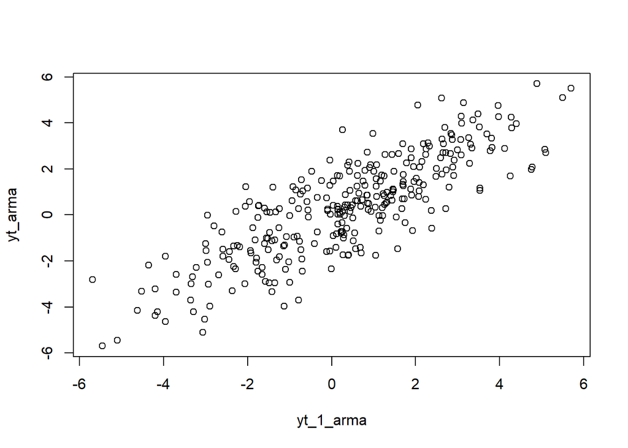

```r
plot(y=yt_arma,x=yt_1_arma)
```

Berdasarkan scatter plot terlihat ada hubungan positif antara $Y_t$ dengan $Y_{t-1}$

#$Y_t$ dengan $Y_{t-2}$

```r
#Yt
yt_arma2 <- arma22[-c(1,2)]
yt_arma2
```

```
##   [1] -5.454951077 -5.694023707 -2.802486053 -0.477633093  1.885681908
##   [6]  1.127038813 -0.693816130 -2.437726544 -1.593852555 -1.246536612
##  [11]  0.263926313 -0.713721594 -1.919947441 -1.654952838 -2.283682722
##  [16] -2.334252509 -2.246035577 -1.329121786  0.131752439  1.708166149
##  [21]  1.438738554  2.623659983  1.779649159  2.252190286  2.874816999
##  [26]  3.266685157  3.357852730  4.122381186  2.890084587  2.085596824
##  [31]  1.407586191  0.832252525  0.867060738  0.222619607 -0.785189966
##  [36]  0.267640463 -1.730479116  0.406819195 -1.742983100  0.390018285
##  [41] -1.749338669 -0.122908566 -1.600026311  0.296095144 -0.854772013
##  [46]  1.074813264  0.793597876  1.289208033  0.510170991 -1.124439275
##  [51] -1.313563450 -1.950580496  0.569838204  0.616238224  1.706300125
##  [56]  1.260106720  0.464285510  0.306328115 -0.038787800  1.276181176
##  [61]  2.622431808  5.077621916  2.842891746  3.533279655  1.161271856
##  [66]  1.467981061  1.075553948  2.183060872  3.081828874  2.593931016
##  [71]  2.490920832  2.017044396  1.593412259  2.655814355  2.698992685
```

[output cut: 45 more lines]

```r
#Yt-2
yt_2_arma <- arma22[-c(299,300)]
yt_2_arma
```

```
##   [1] -3.067197192 -5.100256816 -5.454951077 -5.694023707 -2.802486053
##   [6] -0.477633093  1.885681908  1.127038813 -0.693816130 -2.437726544
##  [11] -1.593852555 -1.246536612  0.263926313 -0.713721594 -1.919947441
##  [16] -1.654952838 -2.283682722 -2.334252509 -2.246035577 -1.329121786
##  [21]  0.131752439  1.708166149  1.438738554  2.623659983  1.779649159
##  [26]  2.252190286  2.874816999  3.266685157  3.357852730  4.122381186
##  [31]  2.890084587  2.085596824  1.407586191  0.832252525  0.867060738
##  [36]  0.222619607 -0.785189966  0.267640463 -1.730479116  0.406819195
##  [41] -1.742983100  0.390018285 -1.749338669 -0.122908566 -1.600026311
##  [46]  0.296095144 -0.854772013  1.074813264  0.793597876  1.289208033
##  [51]  0.510170991 -1.124439275 -1.313563450 -1.950580496  0.569838204
##  [56]  0.616238224  1.706300125  1.260106720  0.464285510  0.306328115
##  [61] -0.038787800  1.276181176  2.622431808  5.077621916  2.842891746
##  [66]  3.533279655  1.161271856  1.467981061  1.075553948  2.183060872
##  [71]  3.081828874  2.593931016  2.490920832  2.017044396  1.593412259
```

[output cut: 45 more lines]

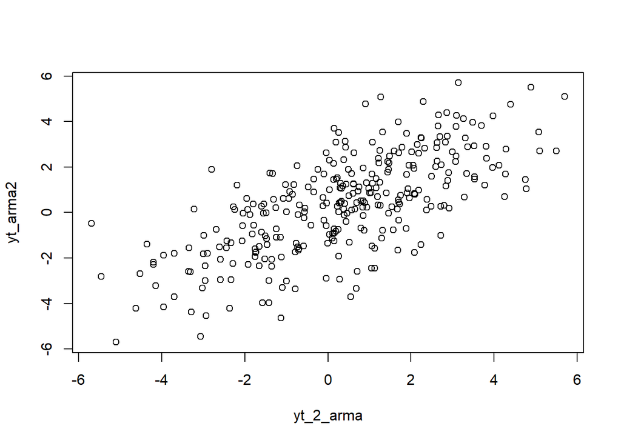

```r
plot(y=yt_arma2,x=yt_2_arma)
```

Berdasarkan scatter plot terlihat ada hubungan positif antara $Y_t$ dengan $Y_{t-2}$

#$Y_t$ dengan $Y_{t-3}$

```r
#Yt
yt_arma3 <- arma22[-c(1,2,3)]
yt_arma3
```

```
##   [1] -5.694023707 -2.802486053 -0.477633093  1.885681908  1.127038813
##   [6] -0.693816130 -2.437726544 -1.593852555 -1.246536612  0.263926313
##  [11] -0.713721594 -1.919947441 -1.654952838 -2.283682722 -2.334252509
##  [16] -2.246035577 -1.329121786  0.131752439  1.708166149  1.438738554
##  [21]  2.623659983  1.779649159  2.252190286  2.874816999  3.266685157
##  [26]  3.357852730  4.122381186  2.890084587  2.085596824  1.407586191
##  [31]  0.832252525  0.867060738  0.222619607 -0.785189966  0.267640463
##  [36] -1.730479116  0.406819195 -1.742983100  0.390018285 -1.749338669
##  [41] -0.122908566 -1.600026311  0.296095144 -0.854772013  1.074813264
##  [46]  0.793597876  1.289208033  0.510170991 -1.124439275 -1.313563450
##  [51] -1.950580496  0.569838204  0.616238224  1.706300125  1.260106720
##  [56]  0.464285510  0.306328115 -0.038787800  1.276181176  2.622431808
##  [61]  5.077621916  2.842891746  3.533279655  1.161271856  1.467981061
##  [66]  1.075553948  2.183060872  3.081828874  2.593931016  2.490920832
##  [71]  2.017044396  1.593412259  2.655814355  2.698992685  3.803267432
```

[output cut: 45 more lines]

```r
#Yt-3
yt_3_arma <- arma22[-c(298,299,300)]
yt_3_arma
```

```
##   [1] -3.067197192 -5.100256816 -5.454951077 -5.694023707 -2.802486053
##   [6] -0.477633093  1.885681908  1.127038813 -0.693816130 -2.437726544
##  [11] -1.593852555 -1.246536612  0.263926313 -0.713721594 -1.919947441
##  [16] -1.654952838 -2.283682722 -2.334252509 -2.246035577 -1.329121786
##  [21]  0.131752439  1.708166149  1.438738554  2.623659983  1.779649159
##  [26]  2.252190286  2.874816999  3.266685157  3.357852730  4.122381186
##  [31]  2.890084587  2.085596824  1.407586191  0.832252525  0.867060738
##  [36]  0.222619607 -0.785189966  0.267640463 -1.730479116  0.406819195
##  [41] -1.742983100  0.390018285 -1.749338669 -0.122908566 -1.600026311
##  [46]  0.296095144 -0.854772013  1.074813264  0.793597876  1.289208033
##  [51]  0.510170991 -1.124439275 -1.313563450 -1.950580496  0.569838204
##  [56]  0.616238224  1.706300125  1.260106720  0.464285510  0.306328115
##  [61] -0.038787800  1.276181176  2.622431808  5.077621916  2.842891746
##  [66]  3.533279655  1.161271856  1.467981061  1.075553948  2.183060872
##  [71]  3.081828874  2.593931016  2.490920832  2.017044396  1.593412259
```

[output cut: 45 more lines]

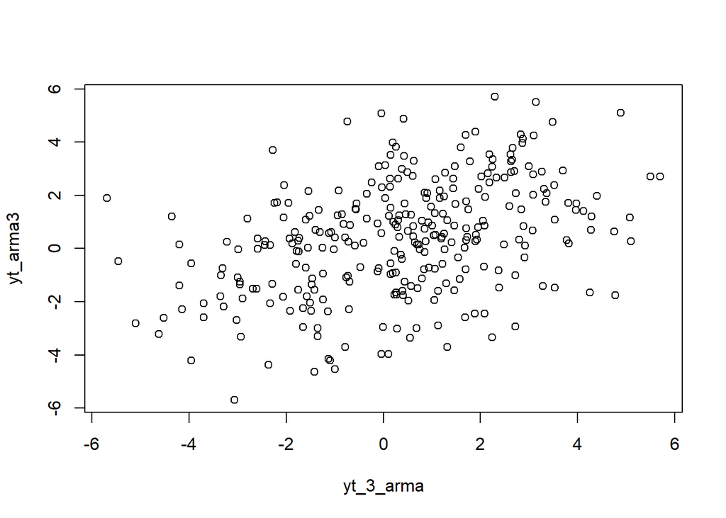

```r
plot(y=yt_arma3,x=yt_3_arma)
```

## Autokorelasi

Hitung autokorelasi masing masing baik dari data bangkitan maupun secara teoritis

```r
cor(yt_arma,yt_1_arma)
```

```
## [1] 0.8270792
```

```r
cor(yt_arma2,yt_2_arma)
```

```
## [1] 0.6942542
```

```r
cor(yt_arma3,yt_3_arma)
```

```
## [1] 0.4123198
```

Belum menemukan rumus korelasi untuk ARMA(2,2), sehingga belum bisa membandingkan.